# TS-Chapter 2 ts graphics

## TS object

**ts: ts(z,start=year,frequency=12)**  
frequency: annual 1,quarterly 4,monthly 12,weekly 52  
z: a numerical vector for ts data

data with **daily observations** might have

1. a **weekly seasonality (frequency=7)** or
2. an **annual seasonality (frequency=365.25)**

data that are observed **every minute** might have

1. an **hourly seasonality (frequency=60)**;
2. a **daily seasonality (frequency=24×60=1440)**;
3. a **weekly seasonality (frequency=24×60×7=10080**;
4. an **annual seasonality (frequency=24×60×365.25=525960)**.  
   If you want to use a ts object, then you need to decide which of these is the most important.

```r
y <- ts(c(3,44,56,89),start=2018,frequency=1)
y
```

A Time Series:

1. 3

2. 44

3. 56

4. 89

## TS Plots

**autoplot**: automatically produces an appropriate plot of whatever you pass to it in the first argument

```r
library(fpp2)
```

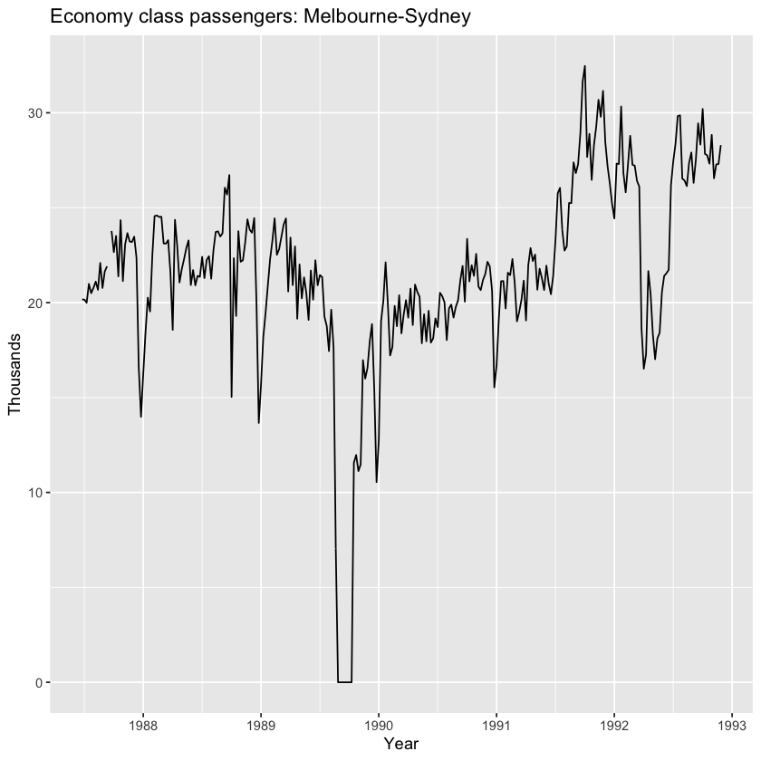

```r
autoplot(melsyd[,"Economy.Class"])+ggtitle("Economy class passengers: Melbourne-Sydney")+
xlab("Year")+ylab("Thousands")
```

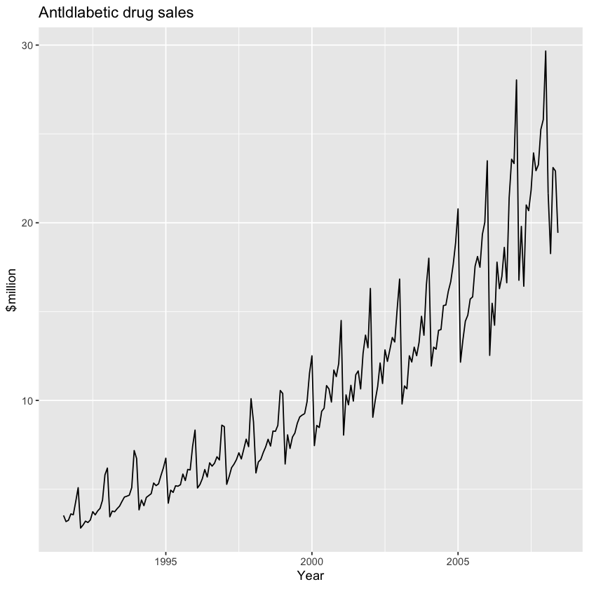

```r
autoplot(a10)+ggtitle("Antldlabetic drug sales")+xlab("Year")+ylab("$million")
```

## TS patterns

**Trend**:A trend exists when there is a long-term increase or decrease in the data.

**Seasonal**:A seasonal pattern occurs when a time series is affected by seasonal factors such as the time of the year or the day of the week.

**Cyclic**:A cycle occurs when the data exhibit rises and falls that are **not of a fixed frequency**. These fluctuations are usually due to economic conditions, and are often related to the “business cycle”

## Seasonal plot

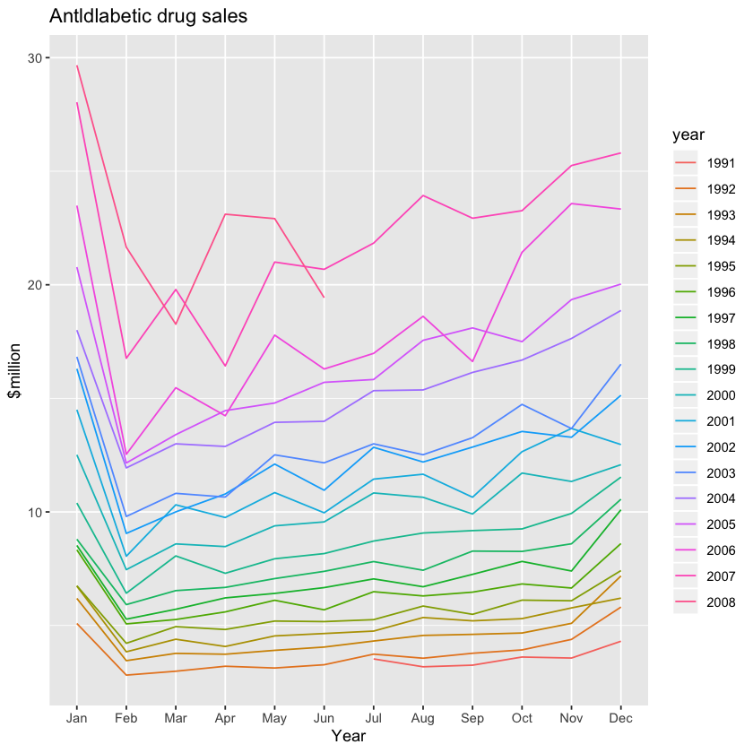

```r
ggseasonplot(a10)+ggtitle("Antldlabetic drug sales")+xlab("Year")+ylab("$million")
```

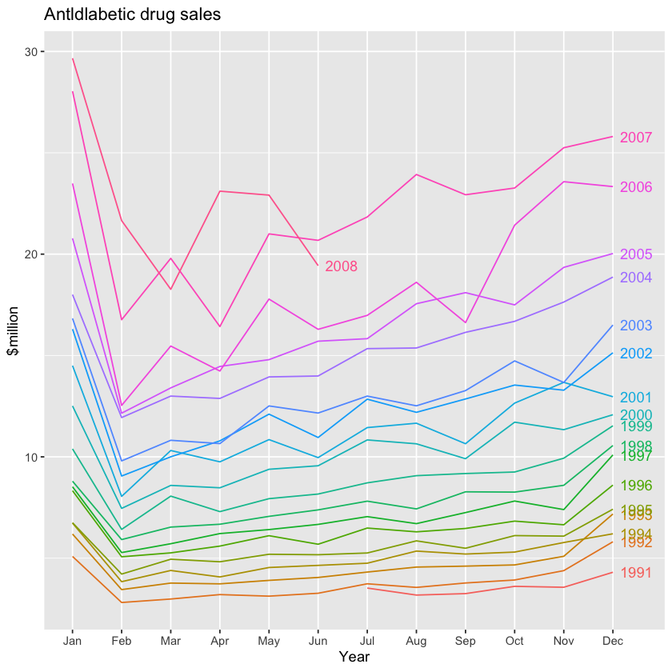

```r
ggseasonplot(a10,,year.labels=TRUE)+ggtitle("Antldlabetic drug sales")+xlab("Year")+ylab("$million")
```

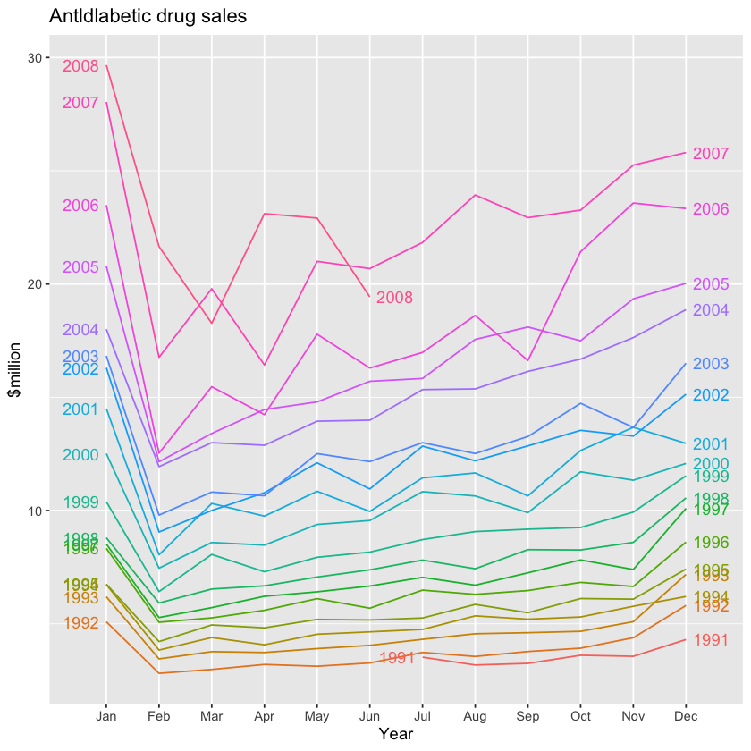

```r
ggseasonplot(a10,year.labels=TRUE,year.labels.left=TRUE)+
ggtitle("Antldlabetic drug sales")+xlab("Year")+ylab("$million")
```

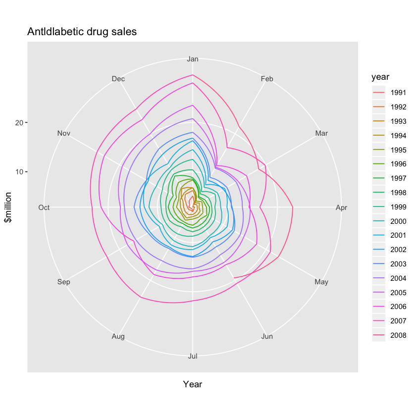

```r
ggseasonplot(a10,polar=TRUE)+ggtitle("Antldlabetic drug sales")+xlab("Year")+ylab("$million")
```

The horizaontal lines (blue lines) represent the means for each month.

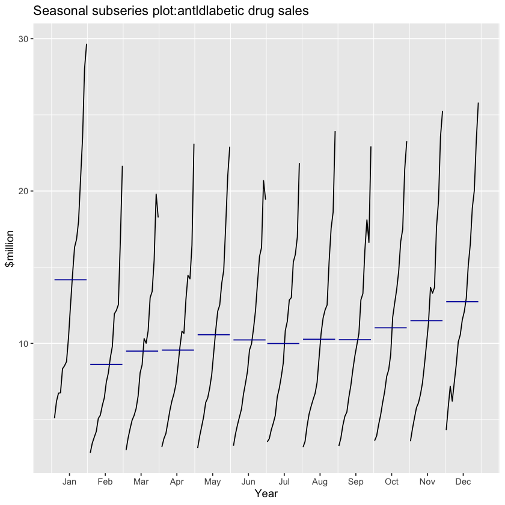

```r
ggsubseriesplot(a10)+ggtitle("Seasonal subseries plot:antldlabetic drug sales")+xlab("Year")+ylab("$million")
```

## Scatter Plot

Scatter plot helps us to visualise the relationship between the variables

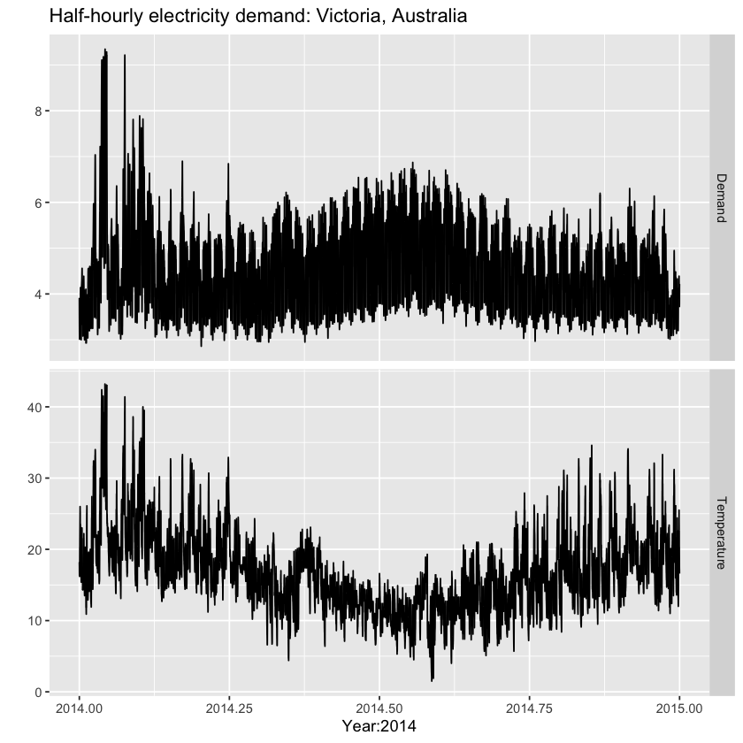

```r
autoplot(elecdemand[,c("Demand","Temperature")],facets=TRUE)+xlab("Year:2014")+ylab("")+
ggtitle("Half-hourly electricity demand: Victoria, Australia")
```

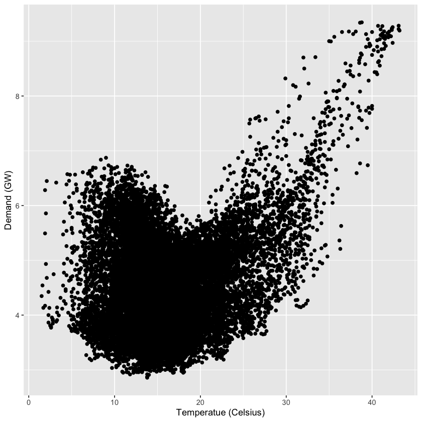

```r
qplot(Temperature,Demand,data=as.data.frame(elecdemand))+ylab("Demand (GW)")+xlab("Temperatue (Celsius)")
```

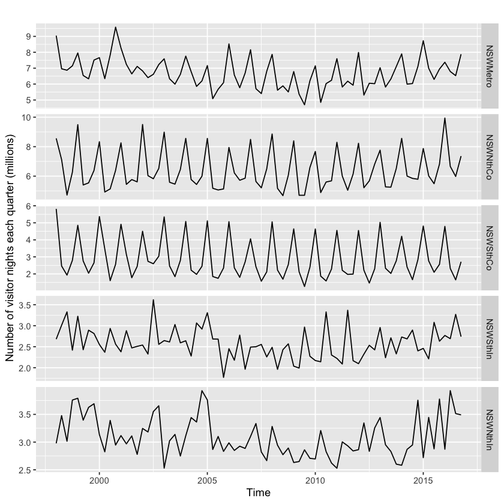

```r
autoplot(visnights[,1:5],facets=TRUE)+ylab("Number of visitor nights each quarter (millions)")
```

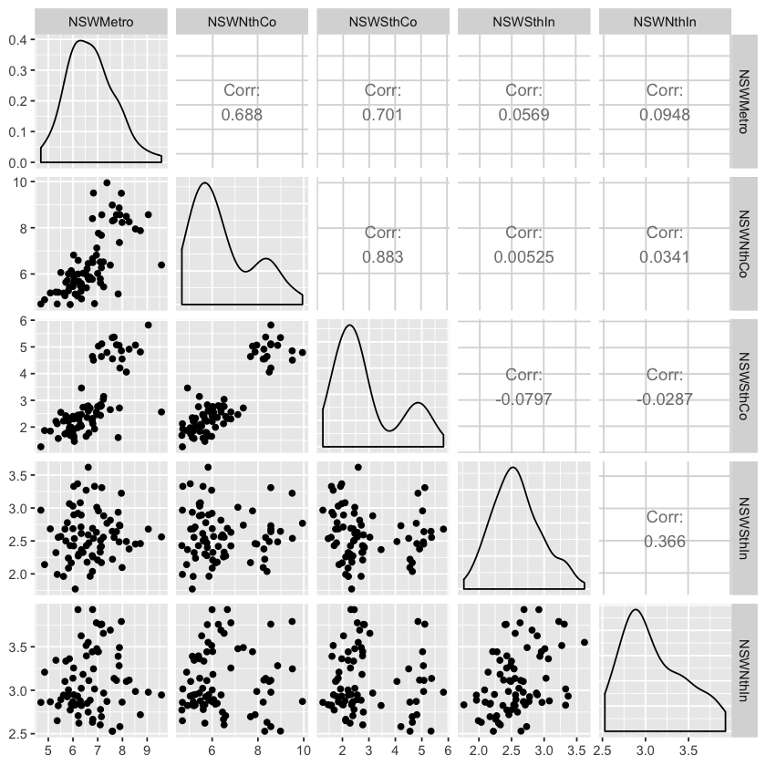

```r
GGally::ggpairs(as.data.frame(visnights[,1:5]))
```

## Lag plots

```r
beer2 <- window(ausbeer,start=1992)
#window: Extract the subset of a 'timeDate' object observed between two time stamps.
```

```r
beer2
```

A Time Series: 19 × 4

|  | Qtr1 | Qtr2 | Qtr3 | Qtr4 |
| --- | --- | --- | --- | --- |
| 1992 | 443 | 410 | 420 | 532 |
| 1993 | 433 | 421 | 410 | 512 |
| 1994 | 449 | 381 | 423 | 531 |
| 1995 | 426 | 408 | 416 | 520 |
| 1996 | 409 | 398 | 398 | 507 |
| 1997 | 432 | 398 | 406 | 526 |
| 1998 | 428 | 397 | 403 | 517 |
| 1999 | 435 | 383 | 424 | 521 |
| 2000 | 421 | 402 | 414 | 500 |
| 2001 | 451 | 380 | 416 | 492 |
| 2002 | 428 | 408 | 406 | 506 |
| 2003 | 435 | 380 | 421 | 490 |
| 2004 | 435 | 390 | 412 | 454 |
| 2005 | 416 | 403 | 408 | 482 |
| 2006 | 438 | 386 | 405 | 491 |
| 2007 | 427 | 383 | 394 | 473 |
| 2008 | 420 | 390 | 410 | 488 |
| 2009 | 415 | 398 | 419 | 488 |
| 2010 | 414 | 374 |  |  |

```r
window(ausbeer,start=1992,end=2000)
```

A Time Series: 9 × 4

|  | Qtr1 | Qtr2 | Qtr3 | Qtr4 |
| --- | --- | --- | --- | --- |
| 1992 | 443 | 410 | 420 | 532 |
| 1993 | 433 | 421 | 410 | 512 |
| 1994 | 449 | 381 | 423 | 531 |
| 1995 | 426 | 408 | 416 | 520 |
| 1996 | 409 | 398 | 398 | 507 |
| 1997 | 432 | 398 | 406 | 526 |
| 1998 | 428 | 397 | 403 | 517 |
| 1999 | 435 | 383 | 424 | 521 |
| 2000 | 421 |  |  |  |

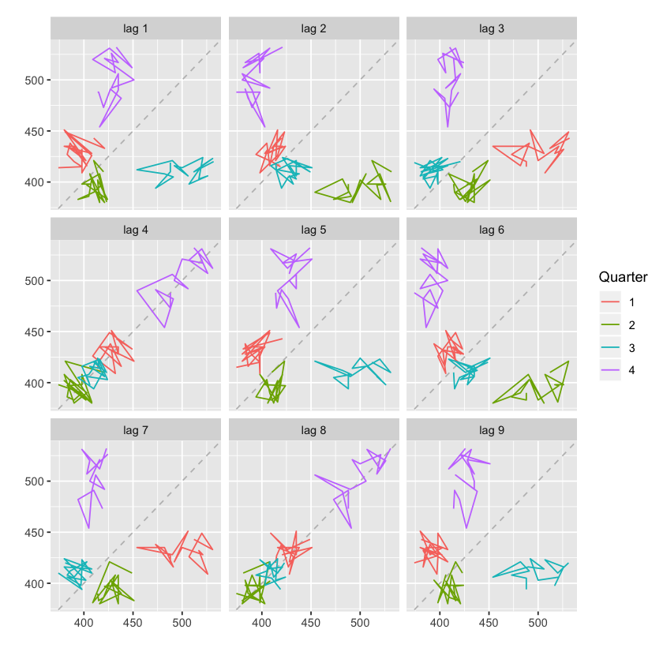

```r
gglagplot(beer2) #lag4 and lag8, strongly positive relationship; lag2 and lag6, strongly negative relationship
```

## Autocorrelation

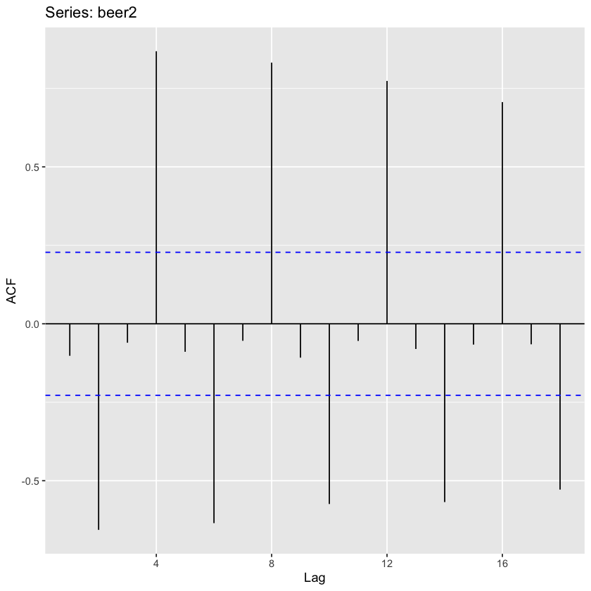

```r
ggAcf(beer2)
#r4 is higher than for the other lags. This is due to the seasonal pattern in the data:
#the peaks tend to be four quarters apart and the troughs tend to be four quarters apart.
```

**Trend**: the autocorrelations for small lags tend to be large and positive because observations nearby in time are also nearby in size. So the ACF of trended time series tend to have positive values that slowly decrease as the lags increase.

**Seasonality**: the autocorrelations will be larger for the seasonal lags (at multiples of the seasonal frequency) than for other lags.

**Trend+Seasonality**: a combination of above effects

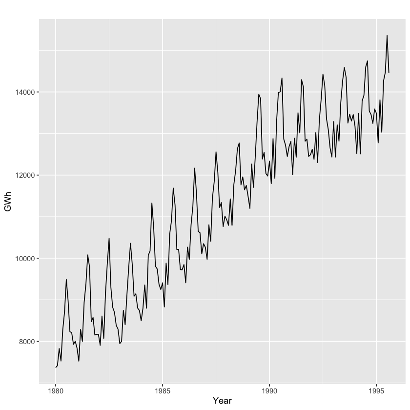

```r
#combine
aelec <- window(elec,start=1980)
autoplot(aelec)+xlab("Year")+ylab("GWh")
```

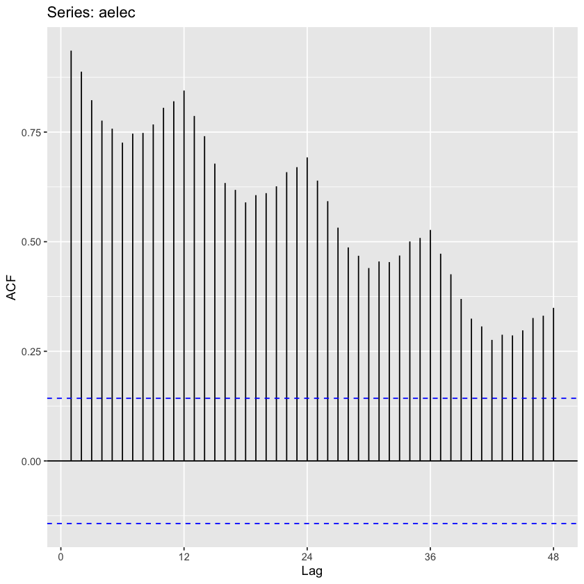

```r
ggAcf(aelec,lag=48)
```

## White noise

```r
set.seed(30)
y <- ts(rnorm(50))
```

```r
y
```

A Time Series:

1. -1.28851820062475

2. -0.347689405260023

3. -0.521628849214455

4. 1.27347316401659

5. 1.82452060134868

6. -1.51130794100387

7. 0.110508045739943

8. -0.760796227598105

9. -0.669897017128139

10. 0.27451968836576

11. -1.02327202024419

12. -1.81939790765856

13. -0.667789810820964

14. -0.0592979926316426

15. 0.880165914775578

16. 0.268512916272135

17. -0.0195793798812284

18. -0.524946972785577

19. -1.40933143199095

20. -1.83398921416691

21. -0.158314294229584

22. 0.754426571017363

23. -0.912129623877029

24. 0.799931140198325

25. 1.49055300024804

26. -1.09640198989762

27. -0.534220686968875

28. -1.42120302730805

29. -1.24273830226432

30. 0.231936178179187

31. -1.72520249568025

32. 0.614860698858126

33. 0.726875140101454

34. -0.042190204196379

35. 0.216001796914866

36. 1.76973638868275

37. 0.220350911239156

38. 0.531478667787331

39. 2.16970096056706

40. -2.93441823798351

41. -0.995564634072697

42. 1.16955321947591

43. -0.480039841600269

44. -1.66886762541605

45. 1.13399719429222

46. -0.317595831171395

47. 0.175857990232157

48. -0.625509546118603

49. -1.63952782104836

50. -0.671484417381168

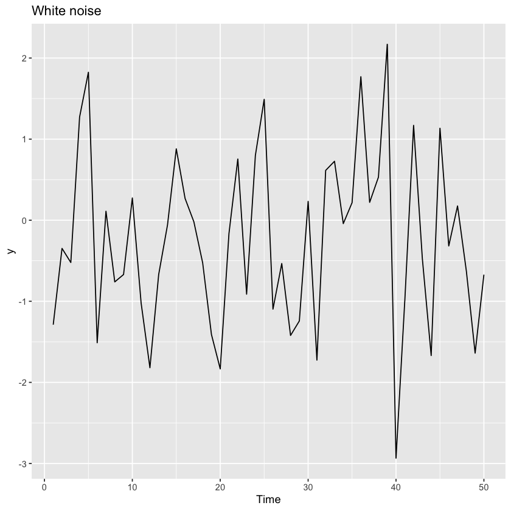

```r
autoplot(y)+ggtitle("White noise")
```

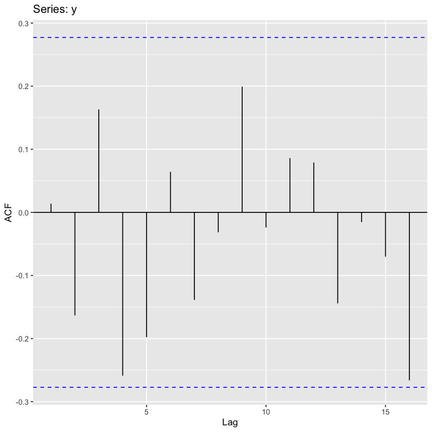

```r
ggAcf(y)
```